# Additional Analyses — H1c/H1d: Human Discriminant Validity and Structural Consistency

Steiger’s Test · Meta-r · Spearman Robustness · AI Surrogate Context

Author

Caroline Müller

Published

May 17, 2026

# 1 Overview

**Prerequisites:** Run the following files first:

- `10_RQ2_data.qmd` → `d_rq3_ai_conditions.rds`
- `20_RQ2_analyses.qmd` → `h1c_ai_results.rds`, `h1d_ai_results.rds`
- `30_RQ3_data.qmd` → `d_human_clean.rds`, `d_rq3_merged.rds`

This file covers H1c (discriminant validity) and H1d (structural consistency) for the **human** participant sample, with AI surrogate results loaded from pre-computed RDS files as context. Sections 3 and 4 follow a parallel structure:

1. **AI surrogate context** — loaded from RDS (all 9 conditions)
2. **Human analysis** — computed here (matched short-3 condition)
3. **Comparison** — human vs AI short-3 condition side by side
4. **Spearman robustness** — same tests with Spearman ρ as approximation

**Note on questionnaire items:** Human Q-Relatedness is scored from 5 items (`q_rel_1`–`q_rel_5`), while AI Q-Relatedness uses 4 items. This difference is inherited from the data preparation step and is explicitly noted wherever it affects interpretation.

**Note on human condition:** All human participants were assessed in the matched short-3 condition (target words = 50, text count = 3). H1c and H1d results for humans are therefore based on a single condition.

# 2 Setup

## 2.1 Environment

## 2.2 Shared Constants

## 2.3 Load Upstream Exports

# 3 H1c — Discriminant Validity

H1c requires that each LLM score dimension correlates more strongly with its matching questionnaire dimension (convergent, r_within) than with non-matching dimensions (discriminant, r_cross). Steiger’s (1980) test for dependent overlapping correlations (`cocor::cocor.dep.groups.overlap`) is used because all three correlation inputs share the same LLM score. Six comparisons per sample: each of three LLM dimensions compared against both non-matching Q dimensions. All tests two-tailed.

The Steiger helpers (`run_steiger_cond`, `run_steiger_cond_spearman`) are defined in `00_common.R`. CI SE is back-computed from the cocor z-statistic to ensure consistency between the p-value and the interval.

## 3.1 AI Surrogate Context

AI H1c results across all 9 conditions are loaded from `h1c_ai_results.rds` (computed in `20_RQ2_analyses.qmd`). The MTMM plot below shows the convergent vs discriminant r pattern for each condition and LLM dimension.

Figure 1: H1c Context: MTMM Validity Coefficient Comparison — AI Surrogates, All 9 Conditions. Filled circle = convergent r (same need); open circles = discriminant r. Discriminant validity holds when the filled circle lies to the right of all open circles in a row.

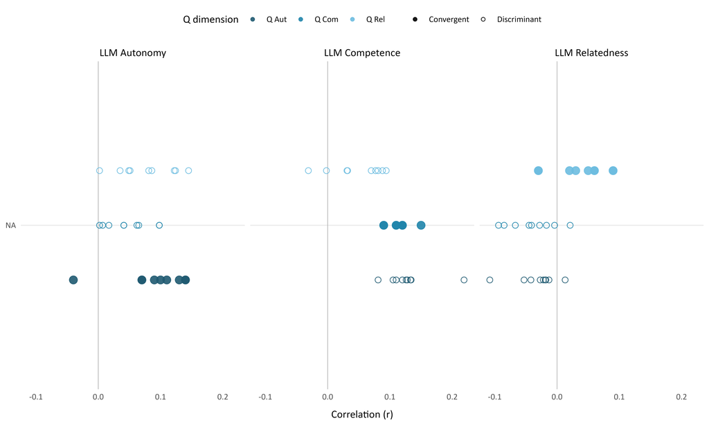

## 3.2 Human H1c Analysis

Six Steiger tests on `d_human_clean` (N = 132). Human condition: short-3 (target words = 50, text count = 3). **Note:** Q-Relatedness for humans uses 5 items (`q_rel_1`–`q_rel_5`); AI uses 4. This applies to both `q_rel_mean` (the composite mean used in all correlations below) and to the inter-need correlations involving relatedness.

Table 1: H1c: Discriminant Validity — Steiger’s Test for Human Participants (Short-3 Condition, N = 6 Tests)

| LLM dim | Comparison | r_within | r_cross | Diff | CI lo | CI hi | z | p | N |
| --- | --- | --- | --- | --- | --- | --- | --- | --- | --- |
| llm_aut_mean | Q_Aut vs Q_Com | 0.19 | 0.129 | 0.056 | -0.11 | 0.22 | 0.67 | 0.502 | 132 |
| llm_aut_mean | Q_Aut vs Q_Rel | 0.19 | 0.152 | 0.033 | -0.13 | 0.19 | 0.41 | 0.683 | 132 |
| llm_com_mean | Q_Com vs Q_Aut | 0.02 | 0.153 | -0.128 | -0.29 | 0.04 | -1.51 | 0.130 | 132 |
| llm_com_mean | Q_Com vs Q_Rel | 0.02 | 0.076 | -0.051 | -0.20 | 0.10 | -0.66 | 0.507 | 132 |
| llm_rel_mean | Q_Rel vs Q_Aut | -0.02 | -0.058 | 0.035 | -0.12 | 0.19 | 0.43 | 0.666 | 132 |
| llm_rel_mean | Q_Rel vs Q_Com | -0.02 | -0.012 | -0.010 | -0.16 | 0.14 | -0.13 | 0.894 | 132 |

Note. Steiger (1980) test for dependent overlapping correlations (cocor::cocor.dep.groups.overlap). Two-tailed. N = 132. r_within = LLM-matching Q correlation (convergent); r_cross = LLM-nonmatching Q correlation (discriminant). CI = 95% Fisher-z CI on r_within − r_cross. Q-Relatedness: 5 items for humans (vs 4 for AI surrogates).

Figure 2: H1c: MTMM Validity Coefficient Comparison — Human Participants (Short-3 Condition). Filled circle = convergent r; open circles = discriminant r. Discriminant validity holds when the filled circle lies to the right of all open circles in each panel.

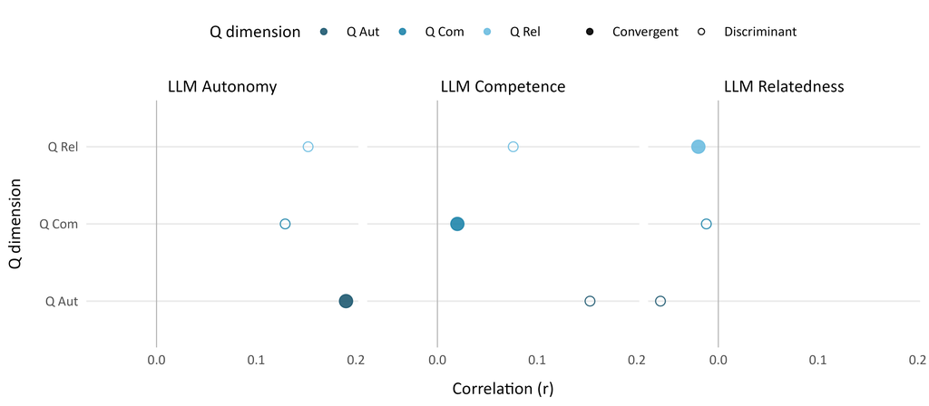

## 3.3 Comparison: Human vs AI Short-3

Table 2: H1c Comparison: Human vs AI Surrogates (Matched Short-3 Condition, target words = 50, text count = 3)

| Group | LLM dim | Comparison | r_within | r_cross | Diff | CI lo | CI hi | z | p | N |
| --- | --- | --- | --- | --- | --- | --- | --- | --- | --- | --- |
| AI (short-3) | llm_aut_mean | Q_Aut vs Q_Com | 0.07 | 0.017 | 0.058 | -0.09 | 0.20 | 0.78 | 0.434 | 394 |
| Human (short-3) | llm_aut_mean | Q_Aut vs Q_Com | 0.19 | 0.129 | 0.056 | -0.11 | 0.22 | 0.67 | 0.502 | 132 |
| AI (short-3) | llm_aut_mean | Q_Aut vs Q_Rel | 0.07 | 0.002 | 0.073 | -0.05 | 0.19 | 1.16 | 0.247 | 394 |
| Human (short-3) | llm_aut_mean | Q_Aut vs Q_Rel | 0.19 | 0.152 | 0.033 | -0.13 | 0.19 | 0.41 | 0.683 | 132 |
| AI (short-3) | llm_com_mean | Q_Com vs Q_Aut | 0.09 | 0.081 | 0.005 | -0.14 | 0.15 | 0.07 | 0.945 | 394 |
| Human (short-3) | llm_com_mean | Q_Com vs Q_Aut | 0.02 | 0.153 | -0.128 | -0.29 | 0.04 | -1.51 | 0.130 | 132 |
| AI (short-3) | llm_com_mean | Q_Com vs Q_Rel | 0.09 | -0.031 | 0.117 | -0.03 | 0.26 | 1.60 | 0.111 | 394 |
| Human (short-3) | llm_com_mean | Q_Com vs Q_Rel | 0.02 | 0.076 | -0.051 | -0.20 | 0.10 | -0.66 | 0.507 | 132 |
| AI (short-3) | llm_rel_mean | Q_Rel vs Q_Aut | 0.09 | -0.013 | 0.107 | -0.02 | 0.23 | 1.71 | 0.088 | 394 |
| Human (short-3) | llm_rel_mean | Q_Rel vs Q_Aut | -0.02 | -0.058 | 0.035 | -0.12 | 0.19 | 0.43 | 0.666 | 132 |
| AI (short-3) | llm_rel_mean | Q_Rel vs Q_Com | 0.09 | -0.004 | 0.099 | -0.05 | 0.24 | 1.35 | 0.178 | 394 |
| Human (short-3) | llm_rel_mean | Q_Rel vs Q_Com | -0.02 | -0.012 | -0.010 | -0.16 | 0.14 | -0.13 | 0.894 | 132 |

Note. AI short-3 results from h1c_ai_results.rds (computed in 20_RQ2_analyses.qmd). Human short-3 results computed above (Section 3.2). Q-Relatedness: AI = 4 items; Human = 5 items.

## 3.4 Spearman Robustness

Steiger’s (1980) test is designed for Pearson r; applying it to Spearman ρ is an approximation. All other test parameters are identical to Section 3.2.

Table 3: H1c Spearman Robustness: Steiger’s Test with Spearman rho — Human Participants (Short-3 Condition; Approximation)

| LLM dim | Comparison | rho_within | rho_cross | Diff | CI lo | CI hi | z | p | N |
| --- | --- | --- | --- | --- | --- | --- | --- | --- | --- |
| llm_aut_mean | Q_Aut vs Q_Com | 0.14 | 0.129 | 0.016 | -0.16 | 0.20 | 0.17 | 0.862 | 132 |
| llm_aut_mean | Q_Aut vs Q_Rel | 0.14 | 0.150 | -0.005 | -0.17 | 0.16 | -0.06 | 0.949 | 132 |
| llm_com_mean | Q_Com vs Q_Aut | 0.00 | 0.155 | -0.156 | -0.33 | 0.02 | -1.70 | 0.089 | 132 |
| llm_com_mean | Q_Com vs Q_Rel | 0.00 | 0.090 | -0.091 | -0.25 | 0.07 | -1.08 | 0.279 | 132 |
| llm_rel_mean | Q_Rel vs Q_Aut | -0.01 | -0.056 | 0.042 | -0.13 | 0.21 | 0.48 | 0.628 | 132 |
| llm_rel_mean | Q_Rel vs Q_Com | -0.01 | 0.034 | -0.048 | -0.21 | 0.12 | -0.57 | 0.566 | 132 |

Note. Steiger (1980) applied to Spearman rho — approximation; compare with Pearson results in tbl-h1c-human. N = 132.

# 4 H1d — Structural Consistency

H1d asks whether the inter-need correlation pattern in LLM scores mirrors the pattern in questionnaire scores. Three inter-need Pearson r values are computed for each source (Q and LLM): Aut–Com, Aut–Rel, Com–Rel. The meta-correlation (meta-r) is the Pearson r between these two 3-element vectors. N = 3 data points — no inferential test is applied; results are descriptive only.

**Note:** Q inter-need correlations for AI surrogates are constant across conditions (Q scores come from one questionnaire administration per persona, independent of scoring condition). For humans there is only one condition (short-3), so meta-r is a single value.

## 4.1 AI Surrogate Context

AI meta-r values per condition (from `h1d_ai_results.rds`) are shown below to provide context before the human result. Condition-to-condition variation reflects shifts in the LLM’s inter-need structure across text length and count.

Table 4: H1d Context: AI Surrogate Meta-r by Condition (N = 9 Conditions, Descriptive Only)

| Condition | Meta-r |
| --- | --- |
| 1 text × 50w | -0.61 |
| 1 text × 150w | -0.41 |
| 1 text × 300w | -0.33 |
| 3 texts × 50w | -0.45 |
| 3 texts × 150w | -0.36 |
| 3 texts × 300w | -0.47 |
| 5 texts × 50w | -0.12 |
| 5 texts × 150w | -0.19 |
| 5 texts × 300w | -0.64 |

Note. meta_r = Pearson r between three Q inter-need correlations and three LLM inter-need correlations per condition. N = 3 pairs; descriptive only. Loaded from h1d_ai_results.rds (computed in 20_RQ2_analyses.qmd).

```
`height` was translated to `width`.
```

Figure 3: H1d Context: Inter-Need Correlations by Instrument, Source, and Condition (Pearson r, 95% CI). Each row is one source: human participants (top, separated by dashed line) or one of the nine AI surrogate conditions. Within each row, two points show the questionnaire inter-need correlation (Q, amber) and the LLM inter-need correlation (LLM, teal). Error bars = 95% CI via Fisher z-transform. AI questionnaire correlations are constant across conditions (same personas, same Q scores). Descriptive only.

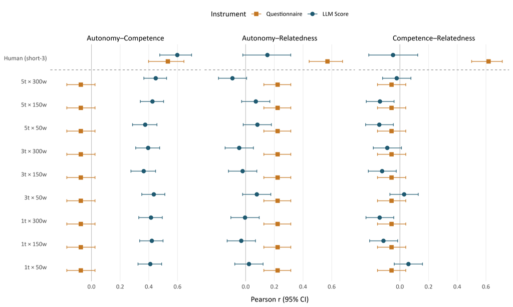

## 4.2 Human H1d Analysis

Table 5: H1d: Structural Consistency — Inter-Need Correlations and Meta-r for Human Participants (Short-3 Condition; N = 3 Pairs, Descriptive Only)

| Need pair | r (Q) | r (LLM) | Meta-r |
| --- | --- | --- | --- |
| Aut-Com | 0.533 | 0.60 | -0.96 |
| Aut-Rel | 0.570 | 0.15 |  |
| Com-Rel | 0.618 | -0.05 |  |

Note. r (Q) = Pearson r between Q composite means (human sample). Q-Relatedness uses 5 items (vs 4 for AI). meta_r = Pearson r between the three Q r-values and three LLM r-values (condition-level statistic, shown once). N = 3 pairs; descriptive only. Sample: N = 132 human participants.

## 4.3 Comparison: Human vs AI Short-3

LLM inter-need correlations for the matched AI short-3 condition (3 texts × 50w) and the human short-3 result are shown side by side per need pair. Dashed grey line = AI Q inter-need r; dotted red line = Human Q inter-need r (5-item relatedness composite).

Figure 4: H1d Comparison: LLM Inter-Need Correlations — AI Surrogate Short-3 vs Human Short-3. Each point = one group. AI surrogate: filled circle (blue); Human: filled diamond (red). Dashed grey line = AI Q inter-need r; dotted red line = Human Q inter-need r (5-item relatedness). Descriptive only; N = 3 pairs per source.

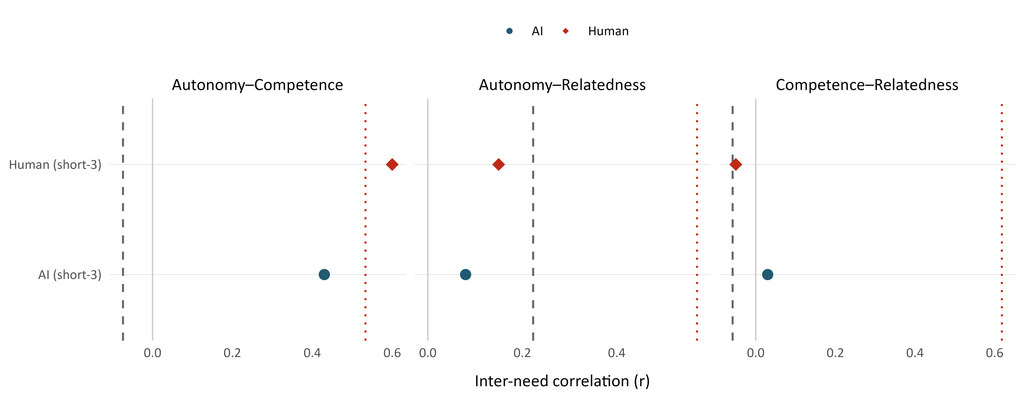

## 4.4 Spearman Robustness

Spearman ρ is substituted for Pearson r in all six inter-need correlations. The meta-r is still Pearson (ranking 3 ρ values is not meaningful), so this tests whether the structural pattern result is robust to rank-based vs linear associations. **Note:** With N = 3 pairs, a single pair’s rank-order shift can change meta-r by ±0.5 or more; the comparison between Pearson and Spearman meta-r values has limited diagnostic power and should be interpreted descriptively.

Table 6: H1d Spearman Robustness: Inter-Need Rho and Meta-r for Human Participants (Short-3 Condition; N = 3 Pairs, Descriptive Only)

| Need pair | rho (Q) | rho (LLM) | Meta-r |
| --- | --- | --- | --- |
| Aut-Com | 0.450 | 0.58 | -0.99 |
| Aut-Rel | 0.521 | 0.17 |  |
| Com-Rel | 0.545 | -0.06 |  |

Note. Spearman rho for all six inter-need correlations; meta-r = Pearson r of the resulting rho vectors. Compare with Pearson results in tbl-h1d-human. N = 132 human participants.

# 5 Supplementary Cross-Group Comparisons

`d_rq3_merged` (AI short-3 + human, matched condition) is used for cross-group descriptive comparisons. The table below provides a quick summary of LLM score means by group and need dimension.

Table 7: Supplementary: LLM Score Descriptives by Group and Need Dimension (Matched Short-3 Condition)

| Group | Need | N | M | SD |
| --- | --- | --- | --- | --- |
| AI surrogates | Autonomy | 394 | 2.94 | 0.40 |
| AI surrogates | Competence | 394 | 3.41 | 0.47 |
| AI surrogates | Relatedness | 394 | 3.07 | 0.40 |
| Humans | Autonomy | 132 | 2.66 | 0.64 |
| Humans | Competence | 132 | 2.58 | 0.55 |
| Humans | Relatedness | 132 | 3.42 | 0.54 |

Note. LLM composite means (3 repeats averaged). AI: matched short-3 condition (target words = 50, text count = 3). Human: short-3 condition.

# 6 Session Info